# Importing necessary libraries

```python
import pandas as pd
import matplotlib.pyplot as plt
import seaborn as sns
import numpy as np
import warnings
import shap
warnings.filterwarnings('ignore')

from imblearn.over_sampling import SMOTE
from sklearn.model_selection import train_test_split, cross_val_score, GridSearchCV
from sklearn.preprocessing import StandardScaler, LabelEncoder, label_binarize
from sklearn.decomposition import PCA
from sklearn.feature_selection import RFE
from sklearn.linear_model import LogisticRegression
from sklearn.ensemble import RandomForestClassifier
from xgboost import XGBClassifier
from sklearn.metrics import confusion_matrix, ConfusionMatrixDisplay, roc_curve, auc, classification_report, accuracy_score, f1_score
from sklearn.neural_network import MLPClassifier
```

# Phase 1: Data Understanding and Preprocessing

## Step 1: Load and Inspect the Dataset

```python
# Load the dataset
file_id = '10SesEJia8bZH4LuNjVwr5B1kX2x_iGYK'
dataset_url = f'https://drive.google.com/uc?id={file_id}'
df = pd.read_csv(dataset_url, sep=';')
```

```python
# Display the first 5 rows
print("First 5 rows of the dataset:")
display(df.head())
```

```
First 5 rows of the dataset:
```

|  | Marital status | Application mode | Application order | Course | Daytime/evening attendance\t | Previous qualification | Previous qualification (grade) | Nacionality | Mother's qualification | Father's qualification | ... | Curricular units 2nd sem (credited) | Curricular units 2nd sem (enrolled) | Curricular units 2nd sem (evaluations) | Curricular units 2nd sem (approved) | Curricular units 2nd sem (grade) | Curricular units 2nd sem (without evaluations) | Unemployment rate | Inflation rate | GDP | Target |
| --- | --- | --- | --- | --- | --- | --- | --- | --- | --- | --- | --- | --- | --- | --- | --- | --- | --- | --- | --- | --- | --- |
| 0 | 1 | 17 | 5 | 171 | 1 | 1 | 122.0 | 1 | 19 | 12 | ... | 0 | 0 | 0 | 0 | 0.000000 | 0 | 10.8 | 1.4 | 1.74 | Dropout |
| 1 | 1 | 15 | 1 | 9254 | 1 | 1 | 160.0 | 1 | 1 | 3 | ... | 0 | 6 | 6 | 6 | 13.666667 | 0 | 13.9 | -0.3 | 0.79 | Graduate |
| 2 | 1 | 1 | 5 | 9070 | 1 | 1 | 122.0 | 1 | 37 | 37 | ... | 0 | 6 | 0 | 0 | 0.000000 | 0 | 10.8 | 1.4 | 1.74 | Dropout |
| 3 | 1 | 17 | 2 | 9773 | 1 | 1 | 122.0 | 1 | 38 | 37 | ... | 0 | 6 | 10 | 5 | 12.400000 | 0 | 9.4 | -0.8 | -3.12 | Graduate |
| 4 | 2 | 39 | 1 | 8014 | 0 | 1 | 100.0 | 1 | 37 | 38 | ... | 0 | 6 | 6 | 6 | 13.000000 | 0 | 13.9 | -0.3 | 0.79 | Graduate |

5 rows × 37 columns

```python
# Display shape of the dataset
print(f"\nDataset contains {df.shape[0]} rows and {df.shape[1]} columns")
```

```
Dataset contains 4424 rows and 37 columns
```

```python
# Display column names and data types
print("\nDataset Info:")
df.info()
```

```
Dataset Info:
<class 'pandas.core.frame.DataFrame'>
RangeIndex: 4424 entries, 0 to 4423
Data columns (total 37 columns):
 #   Column                                          Non-Null Count  Dtype
---  ------                                          --------------  -----
 0   Marital status                                  4424 non-null   int64
 1   Application mode                                4424 non-null   int64
 2   Application order                               4424 non-null   int64
 3   Course                                          4424 non-null   int64
 4   Daytime/evening attendance	                     4424 non-null   int64
 5   Previous qualification                          4424 non-null   int64
 6   Previous qualification (grade)                  4424 non-null   float64
 7   Nacionality                                     4424 non-null   int64
 8   Mother's qualification                          4424 non-null   int64
```

[output cut: 30 more lines]

```python
print("\nSummary Statistics:")
display(df.describe(include='all'))
```

```
Summary Statistics:
```

|  | Marital status | Application mode | Application order | Course | Daytime/evening attendance\t | Previous qualification | Previous qualification (grade) | Nacionality | Mother's qualification | Father's qualification | ... | Curricular units 2nd sem (credited) | Curricular units 2nd sem (enrolled) | Curricular units 2nd sem (evaluations) | Curricular units 2nd sem (approved) | Curricular units 2nd sem (grade) | Curricular units 2nd sem (without evaluations) | Unemployment rate | Inflation rate | GDP | Target |
| --- | --- | --- | --- | --- | --- | --- | --- | --- | --- | --- | --- | --- | --- | --- | --- | --- | --- | --- | --- | --- | --- |
| count | 4424.000000 | 4424.000000 | 4424.000000 | 4424.000000 | 4424.000000 | 4424.000000 | 4424.000000 | 4424.000000 | 4424.000000 | 4424.000000 | ... | 4424.000000 | 4424.000000 | 4424.000000 | 4424.000000 | 4424.000000 | 4424.000000 | 4424.000000 | 4424.000000 | 4424.000000 | 4424 |
| unique | NaN | NaN | NaN | NaN | NaN | NaN | NaN | NaN | NaN | NaN | ... | NaN | NaN | NaN | NaN | NaN | NaN | NaN | NaN | NaN | 3 |
| top | NaN | NaN | NaN | NaN | NaN | NaN | NaN | NaN | NaN | NaN | ... | NaN | NaN | NaN | NaN | NaN | NaN | NaN | NaN | NaN | Graduate |
| freq | NaN | NaN | NaN | NaN | NaN | NaN | NaN | NaN | NaN | NaN | ... | NaN | NaN | NaN | NaN | NaN | NaN | NaN | NaN | NaN | 2209 |
| mean | 1.178571 | 18.669078 | 1.727848 | 8856.642631 | 0.890823 | 4.577758 | 132.613314 | 1.873192 | 19.561935 | 22.275316 | ... | 0.541817 | 6.232143 | 8.063291 | 4.435805 | 10.230206 | 0.150316 | 11.566139 | 1.228029 | 0.001969 | NaN |
| std | 0.605747 | 17.484682 | 1.313793 | 2063.566416 | 0.311897 | 10.216592 | 13.188332 | 6.914514 | 15.603186 | 15.343108 | ... | 1.918546 | 2.195951 | 3.947951 | 3.014764 | 5.210808 | 0.753774 | 2.663850 | 1.382711 | 2.269935 | NaN |
| min | 1.000000 | 1.000000 | 0.000000 | 33.000000 | 0.000000 | 1.000000 | 95.000000 | 1.000000 | 1.000000 | 1.000000 | ... | 0.000000 | 0.000000 | 0.000000 | 0.000000 | 0.000000 | 0.000000 | 7.600000 | -0.800000 | -4.060000 | NaN |
| 25% | 1.000000 | 1.000000 | 1.000000 | 9085.000000 | 1.000000 | 1.000000 | 125.000000 | 1.000000 | 2.000000 | 3.000000 | ... | 0.000000 | 5.000000 | 6.000000 | 2.000000 | 10.750000 | 0.000000 | 9.400000 | 0.300000 | -1.700000 | NaN |
| 50% | 1.000000 | 17.000000 | 1.000000 | 9238.000000 | 1.000000 | 1.000000 | 133.100000 | 1.000000 | 19.000000 | 19.000000 | ... | 0.000000 | 6.000000 | 8.000000 | 5.000000 | 12.200000 | 0.000000 | 11.100000 | 1.400000 | 0.320000 | NaN |
| 75% | 1.000000 | 39.000000 | 2.000000 | 9556.000000 | 1.000000 | 1.000000 | 140.000000 | 1.000000 | 37.000000 | 37.000000 | ... | 0.000000 | 7.000000 | 10.000000 | 6.000000 | 13.333333 | 0.000000 | 13.900000 | 2.600000 | 1.790000 | NaN |
| max | 6.000000 | 57.000000 | 9.000000 | 9991.000000 | 1.000000 | 43.000000 | 190.000000 | 109.000000 | 44.000000 | 44.000000 | ... | 19.000000 | 23.000000 | 33.000000 | 20.000000 | 18.571429 | 12.000000 | 16.200000 | 3.700000 | 3.510000 | NaN |

11 rows × 37 columns

### Observations:

- Loaded and inspected the dataset to verify its structure understand its size and check the data types of each column
- This step ensures:
  - The data was read correctly which is important when custom separators like ; are used in .csv files
  - We know how many rows i.e. examples and columns (features + target) we are working with
  - We can spot immediate issues like wrongly parsed headers or mixed data types

## Step 2: Check for Missing Values

```python
# Check total missing values per column
missing_counts = df.isnull().sum()

# Display only columns with missing values
missing_counts = missing_counts[missing_counts > 0]

if missing_counts.empty:
    print("Missing Value Check: None of the columns contain missing values")
else:
    print("Missing Value Check: Columns with missing values are listed below:")
    print("; ".join(missing_counts.index))
    display(missing_counts)
```

```
Missing Value Check: None of the columns contain missing values
```

### Observations:

- Checked for missing values to ensure data completeness and to detect any gaps that might affect model training or evaluation
- Missing values can lead to biased models if not handled properly especially in models like Logistic Regression or Decision Trees which expect valid input values but observaed none

## Step 3: Check Data Types and Inconsistencies

```python
# Check data types of all columns
print("Column Data Types:\n")
display(df.dtypes)
```

```
Column Data Types:
```

|  | 0 |
| --- | --- |
| Marital status | int64 |
| Application mode | int64 |
| Application order | int64 |
| Course | int64 |
| Daytime/evening attendance\t | int64 |
| Previous qualification | int64 |
| Previous qualification (grade) | float64 |
| Nacionality | int64 |
| Mother's qualification | int64 |
| Father's qualification | int64 |
| Mother's occupation | int64 |
| Father's occupation | int64 |
| Admission grade | float64 |
| Displaced | int64 |
| Educational special needs | int64 |
| Debtor | int64 |
| Tuition fees up to date | int64 |
| Gender | int64 |
| Scholarship holder | int64 |
| Age at enrollment | int64 |
| International | int64 |
| Curricular units 1st sem (credited) | int64 |
| Curricular units 1st sem (enrolled) | int64 |
| Curricular units 1st sem (evaluations) | int64 |
| Curricular units 1st sem (approved) | int64 |
| Curricular units 1st sem (grade) | float64 |
| Curricular units 1st sem (without evaluations) | int64 |
| Curricular units 2nd sem (credited) | int64 |
| Curricular units 2nd sem (enrolled) | int64 |
| Curricular units 2nd sem (evaluations) | int64 |
| Curricular units 2nd sem (approved) | int64 |
| Curricular units 2nd sem (grade) | float64 |
| Curricular units 2nd sem (without evaluations) | int64 |
| Unemployment rate | float64 |
| Inflation rate | float64 |
| GDP | float64 |
| Target | object |

**dtype:** object

```python
# Count of unique values per column (to help spot categoricals)
print("\nUnique Value Counts per Column:")
display(df.nunique().sort_values(ascending=False))
```

```
Unique Value Counts per Column:
```

|  | 0 |
| --- | --- |
| Curricular units 1st sem (grade) | 805 |
| Curricular units 2nd sem (grade) | 786 |
| Admission grade | 620 |
| Previous qualification (grade) | 101 |
| Father's occupation | 46 |
| Age at enrollment | 46 |
| Curricular units 1st sem (evaluations) | 35 |
| Father's qualification | 34 |
| Mother's occupation | 32 |
| Curricular units 2nd sem (evaluations) | 30 |
| Mother's qualification | 29 |
| Curricular units 1st sem (enrolled) | 23 |
| Curricular units 1st sem (approved) | 23 |
| Curricular units 2nd sem (enrolled) | 22 |
| Curricular units 1st sem (credited) | 21 |
| Nacionality | 21 |
| Curricular units 2nd sem (approved) | 20 |
| Curricular units 2nd sem (credited) | 19 |
| Application mode | 18 |
| Previous qualification | 17 |
| Course | 17 |
| Curricular units 1st sem (without evaluations) | 11 |
| Unemployment rate | 10 |
| Curricular units 2nd sem (without evaluations) | 10 |
| GDP | 10 |
| Inflation rate | 9 |
| Application order | 8 |
| Marital status | 6 |
| Target | 3 |
| Daytime/evening attendance\t | 2 |
| International | 2 |
| Gender | 2 |
| Scholarship holder | 2 |
| Educational special needs | 2 |
| Debtor | 2 |
| Displaced | 2 |
| Tuition fees up to date | 2 |

**dtype:** int64

### Observations:

- All input features are typed as either int64 or float64 which is appropriate for numerical and categorical encoding tasks
- The target variable is of type object as expected for a multi class classification task
- Binary indicator variables such as Gender, Debtor and Scholarship holder have only two unique values and require no type conversion
- Columns like Course, Nationality and Application mode have moderate cardinality and will be treated as categorical features in later encoding steps
- A column named "Daytime/evening attendance\t" contains a trailing tab character in its name which should be renamed for consistency and to avoid downstream processing issues
- No immediate inconsistencies were found in data types or value counts

## Step 4: Standardize Dataset

```python
# 1. Clean column names: remove leading/trailing whitespace
df.columns = df.columns.str.strip()

# 2. Rename known incorrect or inconsistent column names
df.rename(columns={
    'Nacionality': 'Nationality',
    'Daytime/evening attendance\t': 'Daytime/evening attendance'
}, inplace=True)

# 3. Standardize string values in 'Target' column
df['Target'] = df['Target'].str.strip().str.lower()

df.head()
```

|  | Marital status | Application mode | Application order | Course | Daytime/evening attendance | Previous qualification | Previous qualification (grade) | Nationality | Mother's qualification | Father's qualification | ... | Curricular units 2nd sem (credited) | Curricular units 2nd sem (enrolled) | Curricular units 2nd sem (evaluations) | Curricular units 2nd sem (approved) | Curricular units 2nd sem (grade) | Curricular units 2nd sem (without evaluations) | Unemployment rate | Inflation rate | GDP | Target |
| --- | --- | --- | --- | --- | --- | --- | --- | --- | --- | --- | --- | --- | --- | --- | --- | --- | --- | --- | --- | --- | --- |
| 0 | 1 | 17 | 5 | 171 | 1 | 1 | 122.0 | 1 | 19 | 12 | ... | 0 | 0 | 0 | 0 | 0.000000 | 0 | 10.8 | 1.4 | 1.74 | dropout |
| 1 | 1 | 15 | 1 | 9254 | 1 | 1 | 160.0 | 1 | 1 | 3 | ... | 0 | 6 | 6 | 6 | 13.666667 | 0 | 13.9 | -0.3 | 0.79 | graduate |
| 2 | 1 | 1 | 5 | 9070 | 1 | 1 | 122.0 | 1 | 37 | 37 | ... | 0 | 6 | 0 | 0 | 0.000000 | 0 | 10.8 | 1.4 | 1.74 | dropout |
| 3 | 1 | 17 | 2 | 9773 | 1 | 1 | 122.0 | 1 | 38 | 37 | ... | 0 | 6 | 10 | 5 | 12.400000 | 0 | 9.4 | -0.8 | -3.12 | graduate |
| 4 | 2 | 39 | 1 | 8014 | 0 | 1 | 100.0 | 1 | 37 | 38 | ... | 0 | 6 | 6 | 6 | 13.000000 | 0 | 13.9 | -0.3 | 0.79 | graduate |

5 rows × 37 columns

```python
# 4. Display unique values for each column in the dataset
for col in df.columns:
    unique_vals = df[col].unique()
    print(f"Column: {col}")
    print(f"Unique Values ({len(unique_vals)}): {unique_vals}")
    print("-" * 60)
```

```
Column: Marital status
Unique Values (6): [1 2 4 3 5 6]
------------------------------------------------------------
Column: Application mode
Unique Values (18): [17 15  1 39 18 53 44 51 43  7 42 16  5  2 10 57 26 27]
------------------------------------------------------------
Column: Application order
Unique Values (8): [5 1 2 4 3 6 9 0]
------------------------------------------------------------
Column: Course
Unique Values (17): [ 171 9254 9070 9773 8014 9991 9500 9238 9670 9853 9085 9130 9556 9147
 9003   33 9119]
------------------------------------------------------------
Column: Daytime/evening attendance
Unique Values (2): [1 0]
------------------------------------------------------------
Column: Previous qualification
Unique Values (17): [ 1 19 42 39 10  3 40  2  4 12 43 15  6  9 38  5 14]
------------------------------------------------------------
Column: Previous qualification (grade)
Unique Values (101): [122.  160.  100.  133.1 142.  119.  137.  138.  139.  136.  133.  110.
 149.  127.  135.  140.  125.  126.  151.  115.  150.  143.  130.  120.
 103.  154.  132.  167.  129.  141.  116.  148.  118.  106.  121.  114.
 124.  123.  113.  111.  131.  158.  146.  117.  153.  178.   99.  134.
 128.  170.  155.  145.  152.  112.  107.  156.  188.   96.  161.  166.
 147.  144.  102.  101.  180.  172.  105.  108.  165.  190.  162.  164.
 163.  159.  117.4 175.  133.8 176.  168.  139.3  97.  157.  140.8 184.4
 148.9 109.  174.  182.  138.6  95.  154.4 163.3 145.7 123.9 124.4 169.
 177.  138.7 119.1 118.9 126.6]
------------------------------------------------------------
Column: Nationality
Unique Values (21): [  1  62   6  41  26 103  13  25  21 101  11  22  32 100  24 109   2 108
 105  14  17]
------------------------------------------------------------
Column: Mother's qualification
Unique Values (29): [19  1 37 38  3  4 42  2 34 12 40  9  5 39 11 41 30 14 35 36  6 10 29 43
 18 22 27 26 44]
------------------------------------------------------------
Column: Father's qualification
Unique Values (34): [12  3 37 38  1 19  5  4 34  2 39 11  9 36 26 40 14 20 35 41 22 13 29 43
```

[output cut: 389 more lines]

```
Column: Curricular units 2nd sem (without evaluations)
Unique Values (10): [ 0  5  2  1  3  6  4 12  7  8]
------------------------------------------------------------
Column: Unemployment rate
Unique Values (10): [10.8 13.9  9.4 16.2 15.5  8.9 12.7 11.1  7.6 12.4]
------------------------------------------------------------
Column: Inflation rate
Unique Values (9): [ 1.4 -0.3 -0.8  0.3  2.8  3.7  0.6  2.6  0.5]
------------------------------------------------------------
Column: GDP
Unique Values (10): [ 1.74  0.79 -3.12 -0.92 -4.06  3.51 -1.7   2.02  0.32  1.79]
------------------------------------------------------------
Column: Target
Unique Values (3): ['dropout' 'graduate' 'enrolled']
------------------------------------------------------------
```

## Step 5: Descriptive Statistics and Univariate EDA

```python
low_card_cols = df.nunique()[df.nunique() < 25].index.tolist()
print("Columns with fewer than 25 unique values (possible categorical codes):")
print(low_card_cols)
```

```
Columns with fewer than 25 unique values (possible categorical codes):
['Marital status', 'Application mode', 'Application order', 'Course', 'Daytime/evening attendance', 'Previous qualification', 'Nationality', 'Displaced', 'Educational special needs', 'Debtor', 'Tuition fees up to date', 'Gender', 'Scholarship holder', 'International', 'Curricular units 1st sem (cred…
```

```python
for col in low_card_cols:
    print(f"{col} - Unique Values: {sorted(df[col].unique())}")
```

```
Marital status - Unique Values: [np.int64(1), np.int64(2), np.int64(3), np.int64(4), np.int64(5), np.int64(6)]
Application mode - Unique Values: [np.int64(1), np.int64(2), np.int64(5), np.int64(7), np.int64(10), np.int64(15), np.int64(16), np.int64(17), np.int64(18), np.int64(26), np.int64(27), np.int64(39), np.int64(42), np.int64(43), np.int64(44), np.int64(51), np.int64(53), np.int64(57)]
Application order - Unique Values: [np.int64(0), np.int64(1), np.int64(2), np.int64(3), np.int64(4), np.int64(5), np.int64(6), np.int64(9)]
Course - Unique Values: [np.int64(33), np.int64(171), np.int64(8014), np.int64(9003), np.int64(9070), np.int64(9085), np.int64(9119), np.int64(9130), np.int64(9147), np.int64(9238), np.int64(9254), np.int64(9500), np.int64(9556), np.int64(9670), np.int64(9773), np.int64(9853), np.int64(9991)]
Daytime/evening attendance - Unique Values: [np.int64(0), np.int64(1)]
Previous qualification - Unique Values: [np.int64(1), np.int64(2), np.int64(3), np.int64(4), np.int64(5), np.int64(6), np.int64(9), np.int64(10), np.int64(12), np.int64(14), np.int64(15), np.int64(19), np.int64(38), np.int64(39), np.int64(40), np.int64(42), np.int64(43)]
Nationality - Unique Values: [np.int64(1), np.int64(2), np.int64(6), np.int64(11), np.int64(13), np.int64(14), np.int64(17), np.int64(21), np.int64(22), np.int64(24), np.int64(25), np.int64(26), np.int64(32), np.int64(41), np.int64(62), np.int64(100), np.int64(101), np.int64(103), np.int64(105), np.…
Displaced - Unique Values: [np.int64(0), np.int64(1)]
Educational special needs - Unique Values: [np.int64(0), np.int64(1)]
Debtor - Unique Values: [np.int64(0), np.int64(1)]
Tuition fees up to date - Unique Values: [np.int64(0), np.int64(1)]
Gender - Unique Values: [np.int64(0), np.int64(1)]
Scholarship holder - Unique Values: [np.int64(0), np.int64(1)]
International - Unique Values: [np.int64(0), np.int64(1)]
Curricular units 1st sem (credited) - Unique Values: [np.int64(0), np.int64(1), np.int64(2), np.int64(3), np.int64(4), np.int64(5), np.int64(6), np.int64(7), np.int64(8), np.int64(9), np.int64(10), np.int64(11), np.int64(12), np.int64(13), np.int64(14), np.int64(15), np.int64(16), np.int64(17), np.i…
Curricular units 1st sem (enrolled) - Unique Values: [np.int64(0), np.int64(1), np.int64(2), np.int64(3), np.int64(4), np.int64(5), np.int64(6), np.int64(7), np.int64(8), np.int64(9), np.int64(10), np.int64(11), np.int64(12), np.int64(13), np.int64(14), np.int64(15), np.int64(16), np.int64(17), np.i…
Curricular units 1st sem (approved) - Unique Values: [np.int64(0), np.int64(1), np.int64(2), np.int64(3), np.int64(4), np.int64(5), np.int64(6), np.int64(7), np.int64(8), np.int64(9), np.int64(10), np.int64(11), np.int64(12), np.int64(13), np.int64(14), np.int64(15), np.int64(16), np.int64(17), np.i…
Curricular units 1st sem (without evaluations) - Unique Values: [np.int64(0), np.int64(1), np.int64(2), np.int64(3), np.int64(4), np.int64(5), np.int64(6), np.int64(7), np.int64(8), np.int64(10), np.int64(12)]
Curricular units 2nd sem (credited) - Unique Values: [np.int64(0), np.int64(1), np.int64(2), np.int64(3), np.int64(4), np.int64(5), np.int64(6), np.int64(7), np.int64(8), np.int64(9), np.int64(10), np.int64(11), np.int64(12), np.int64(13), np.int64(14), np.int64(15), np.int64(16), np.int64(18), np.i…
Curricular units 2nd sem (enrolled) - Unique Values: [np.int64(0), np.int64(1), np.int64(2), np.int64(3), np.int64(4), np.int64(5), np.int64(6), np.int64(7), np.int64(8), np.int64(9), np.int64(10), np.int64(11), np.int64(12), np.int64(13), np.int64(14), np.int64(15), np.int64(16), np.int64(17), np.i…
Curricular units 2nd sem (approved) - Unique Values: [np.int64(0), np.int64(1), np.int64(2), np.int64(3), np.int64(4), np.int64(5), np.int64(6), np.int64(7), np.int64(8), np.int64(9), np.int64(10), np.int64(11), np.int64(12), np.int64(13), np.int64(14), np.int64(16), np.int64(17), np.int64(18), np.i…
Curricular units 2nd sem (without evaluations) - Unique Values: [np.int64(0), np.int64(1), np.int64(2), np.int64(3), np.int64(4), np.int64(5), np.int64(6), np.int64(7), np.int64(8), np.int64(12)]
Unemployment rate - Unique Values: [np.float64(7.6), np.float64(8.9), np.float64(9.4), np.float64(10.8), np.float64(11.1), np.float64(12.4), np.float64(12.7), np.float64(13.9), np.float64(15.5), np.float64(16.2)]
Inflation rate - Unique Values: [np.float64(-0.8), np.float64(-0.3), np.float64(0.3), np.float64(0.5), np.float64(0.6), np.float64(1.4), np.float64(2.6), np.float64(2.8), np.float64(3.7)]
GDP - Unique Values: [np.float64(-4.06), np.float64(-3.12), np.float64(-1.7), np.float64(-0.92), np.float64(0.32), np.float64(0.79), np.float64(1.74), np.float64(1.79), np.float64(2.02), np.float64(3.51)]
Target - Unique Values: ['dropout', 'enrolled', 'graduate']
```

```python
# Descriptive Statistics for Continuous Numerical Features

# Justification:
# The following list of continuous_vars is hard coded intentionally
# based on manual classification and domain understanding see classification table below
# These variables are true continuous measures (grades, economic indicators)
# and not discrete counts or coded categories even if other numeric columns exist

continuous_vars = [
    'Admission grade',
    'Previous qualification (grade)',
    'Curricular units 1st sem (grade)',
    'Curricular units 2nd sem (grade)',
    'Unemployment rate',
    'Inflation rate',
    'GDP'
]

# Display descriptive statistics for continuous numerical features
print("Descriptive Statistics for Continuous Numerical Features:")
display(df[continuous_vars].describe().T)
```

```
Descriptive Statistics for Continuous Numerical Features:
```

|  | count | mean | std | min | 25% | 50% | 75% | max |
| --- | --- | --- | --- | --- | --- | --- | --- | --- |
| Admission grade | 4424.0 | 126.978119 | 14.482001 | 95.00 | 117.90 | 126.100000 | 134.800000 | 190.000000 |
| Previous qualification (grade) | 4424.0 | 132.613314 | 13.188332 | 95.00 | 125.00 | 133.100000 | 140.000000 | 190.000000 |
| Curricular units 1st sem (grade) | 4424.0 | 10.640822 | 4.843663 | 0.00 | 11.00 | 12.285714 | 13.400000 | 18.875000 |
| Curricular units 2nd sem (grade) | 4424.0 | 10.230206 | 5.210808 | 0.00 | 10.75 | 12.200000 | 13.333333 | 18.571429 |
| Unemployment rate | 4424.0 | 11.566139 | 2.663850 | 7.60 | 9.40 | 11.100000 | 13.900000 | 16.200000 |
| Inflation rate | 4424.0 | 1.228029 | 1.382711 | -0.80 | 0.30 | 1.400000 | 2.600000 | 3.700000 |
| GDP | 4424.0 | 0.001969 | 2.269935 | -4.06 | -1.70 | 0.320000 | 1.790000 | 3.510000 |

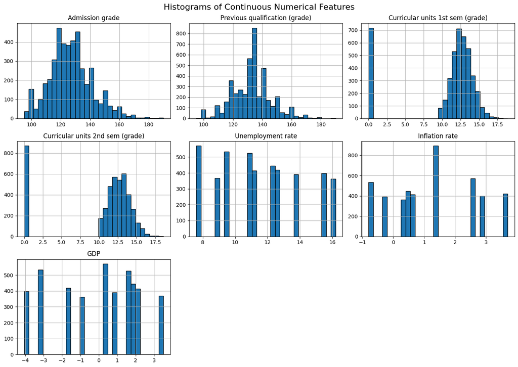

```python
# Plot histograms only for validated continuous features
df[continuous_vars].hist(figsize=(14, 10), bins=30, edgecolor='black')

plt.suptitle("Histograms of Continuous Numerical Features", fontsize=16)
plt.tight_layout()
plt.show()
```